# Quarto Exercise 6

Times Higher Education World University Rankings

Author

Xu Du

## Data and packages

The analysis uses the [CSV specified in the exercise](https://manctsui.github.io/datasets/timesData.csv). The rankings are historical records, not current rankings.

**R code**

```r
library(dplyr)
```

**R code**

```r
library(ggplot2)
library(DT)
library(plotly)
```

**R code**

```r
library(crosstalk)
library(htmltools)

# Give the data download enough time on a slower connection.
options(timeout = max(300, getOption("timeout")))

times <- read.csv(
  "https://manctsui.github.io/datasets/timesData.csv",
  stringsAsFactors = FALSE,
  na.strings = c("", "NA", "-"),
  fileEncoding = "UTF-8"
)

times <- times %>%
  mutate(
    university_name = trimws(university_name),
    country = trimws(country),
    world_rank = trimws(world_rank)
  )
```

The dataset contains 2603 records covering 2011 to 2016.

## Problem 1A: Countries with the most ranking appearances

The second column counts appearances across all years. A university appearing in several years is counted once for each appearance, rather than only once in total.

**R code**

```r
top_countries <- times %>%
  count(country, name = "appearances", sort = TRUE) %>%
  slice(1:3)

DT::datatable(
  top_countries,
  rownames = FALSE,
  colnames = c("Country", "Ranking appearances"),
  selection = "none",
  options = list(
    dom = "t",
    paging = FALSE,
    order = list(list(1, "desc"))
  )
)
```

| Country | Ranking appearances |
| --- | --- |
| United States of America | 659 |
| United Kingdom | 300 |
| Germany | 152 |

## Problem 1B: Bar chart

**R code**

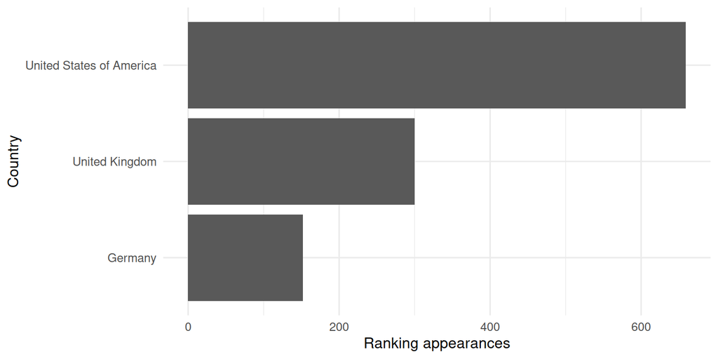

Figure 1: The three countries with the most appearances in the assigned ranking dataset.

```r
ggplot(
  top_countries,
  aes(x = reorder(country, appearances), y = appearances)
) +
  geom_col() +
  coord_flip() +
  labs(
    x = "Country",
    y = "Ranking appearances"
  ) +
  theme_minimal(base_size = 12)
```

## Problem 2A: Top 50 universities in 2011

The table contains only rank and university name. Tied ranks are retained.

**R code**

```r
top50_2011 <- times %>%
  filter(year == 2011) %>%
  # Keep exact ranks, optionally prefixed with an equals sign.
  # A ranking band such as "201-225" is not an exact rank.
  filter(grepl("^=?[0-9]+$", world_rank)) %>%
  mutate(rank = as.numeric(sub("^=", "", world_rank))) %>%
  filter(rank >= 1, rank <= 50) %>%
  arrange(rank, university_name) %>%
  select(rank, university_name)

DT::datatable(
  top50_2011,
  rownames = FALSE,
  colnames = c("Rank", "University name"),
  selection = "none",
  options = list(
    pageLength = 10,
    lengthMenu = c(10, 25, 50),
    order = list(list(0, "asc"))
  )
)
```

| Rank | University name |
| --- | --- |
| 1 | Harvard University |
| 2 | California Institute of Technology |
| 3 | Massachusetts Institute of Technology |
| 4 | Stanford University |
| 5 | Princeton University |
| 6 | University of Cambridge |
| 6 | University of Oxford |
| 8 | University of California, Berkeley |
| 9 | Imperial College London |
| 10 | Yale University |

[output cut: 40 more lines]

There are 50 universities in this selection. Use the page controls to view all rows.

## Problem 2B: Is rank a good key?

The question refers to the result of **Problem 1A**, but that table has only country and appearance count, not a rank column. As written, `$rank` is therefore not available as a key for that table.

For the university table in **Problem 2A**, rank is also not a good key because different universities can have the same rank. For example, Cambridge and Oxford are both ranked 6 in the 2011 data. A Crosstalk key must uniquely identify a row and must not be missing or empty. It should also remain stable.[^1]

The following code identifies repeated ranks in the 2011 top-50 table:

**R code**

```r
top50_2011 %>%
  count(rank, name = "universities") %>%
  filter(universities > 1)
```

```
  rank universities
1    6            2
2   15            2
3   30            2
4   43            4
5   49            2
```

For this single-year table, the next section uses university name as the key and checks that it is unique and nonmissing first. For the 2016 plots, a year-and-university key identifies each observation.

## Problem 2C: Filter universities by rank

This repeats the two-column table from Problem 2A with a rank slider. Move either handle to change the rank interval. Reset the handles to the minimum and maximum to show all universities again.

**R code**

```r
# The key is stored by SharedData; it does not add a visible table column.
stopifnot(
  nrow(top50_2011) > 0,
  !anyNA(top50_2011$university_name),
  all(nzchar(top50_2011$university_name)),
  anyDuplicated(top50_2011$university_name) == 0
)

shared_top50 <- SharedData$new(
  top50_2011,
  key = ~university_name,
  group = "top50-2011"
)

htmltools::tagList(
  filter_slider(
    id = "rank-range-2011",
    label = "World rank in 2011",
    sharedData = shared_top50,
    column = ~rank,
    step = 1,
    width = "100%"
  ),
  DT::datatable(
    shared_top50,
    rownames = FALSE,
    colnames = c("Rank", "University name"),
    selection = "none",
    options = list(
      pageLength = 10,
      lengthMenu = c(10, 25, 50),
      order = list(list(0, "asc"))
    )
  )
)
```

World rank in 2011

| Rank | University name |
| --- | --- |
| 1 | Harvard University |
| 2 | California Institute of Technology |
| 3 | Massachusetts Institute of Technology |
| 4 | Stanford University |
| 5 | Princeton University |
| 6 | University of Cambridge |
| 6 | University of Oxford |
| 8 | University of California, Berkeley |
| 9 | Imperial College London |
| 10 | Yale University |

[output cut: 40 more lines]

## Problem 3: Linked scatterplots for 2016

The first plot shows number of students on the horizontal axis and student-staff ratio on the vertical axis. The second shows student-staff ratio on the horizontal axis and teaching score on the vertical axis.

I remove commas from student counts before converting them to numbers. To use the same observations in both plots, I retain only the 2016 rows with all three measures available. Missing values are not replaced with zero.

**R code**

```r
data_2016 <- times %>%
  filter(year == 2016) %>%
  transmute(
    university_name,
    students = as.numeric(gsub(",", "", num_students)),
    student_staff_ratio = as.numeric(student_staff_ratio),
    teaching = as.numeric(teaching),
    university_key = paste(year, university_name, sep = "::")
  )

plot_data <- data_2016 %>%
  filter(
    !is.na(students),
    !is.na(student_staff_ratio),
    !is.na(teaching)
  )

stopifnot(
  nrow(plot_data) > 0,
  !anyNA(plot_data$university_name),
  all(nzchar(plot_data$university_name)),
  anyDuplicated(plot_data$university_key) == 0
)

# Both plots receive the SAME SharedData object.
shared_2016 <- SharedData$new(
  plot_data,
  key = ~university_key,
  group = "universities-2016"
)
```

Both plots use **793 of 800** 2016 records. **7** records are excluded because at least one of the three measures is missing.

**R code**

```r
p_students <- plot_ly(
  shared_2016,
  x = ~students,
  y = ~student_staff_ratio,
  text = ~paste0(
    university_name,
    "<br>Students: ", students,
    "<br>Student-staff ratio: ", student_staff_ratio
  ),
  hoverinfo = "text",
  type = "scatter",
  mode = "markers",
  marker = list(size = 6, opacity = 0.75),
  height = 400
) %>%
  plotly::layout(
    xaxis = list(title = "Number of students"),
    yaxis = list(title = "Student-staff ratio"),
    dragmode = "select",
    showlegend = FALSE,
    margin = list(l = 70, r = 15, t = 20, b = 60)
  ) %>%
  highlight(
    on = "plotly_selected",
    off = "plotly_deselect",
    persistent = FALSE,
    opacityDim = 0.15
  ) %>%
  config(displaylogo = FALSE, responsive = TRUE)
```

**R code**

```r
p_teaching <- plot_ly(
  shared_2016,
  x = ~student_staff_ratio,
  y = ~teaching,
  text = ~paste0(
    university_name,
    "<br>Student-staff ratio: ", student_staff_ratio,
    "<br>Teaching score: ", teaching
  ),
  hoverinfo = "text",
  type = "scatter",
  mode = "markers",
  marker = list(size = 6, opacity = 0.75),
  height = 400
) %>%
  plotly::layout(
    xaxis = list(title = "Student-staff ratio"),
    yaxis = list(title = "Teaching score"),
    dragmode = "select",
    showlegend = FALSE,
    margin = list(l = 70, r = 15, t = 20, b = 60)
  ) %>%
  highlight(
    on = "plotly_selected",
    off = "plotly_deselect",
    persistent = FALSE,
    opacityDim = 0.15
  ) %>%
  config(displaylogo = FALSE, responsive = TRUE)
```

**Interaction:** Drag a rectangle around points in either plot. The matching universities are highlighted in the other plot because the plots share the same Crosstalk keys. Double-click inside a plot while in selection mode to clear the selection.[^2]

### Students and student-staff ratio

[interactive chart not shown]

### Student-staff ratio and teaching

[interactive chart not shown]

## Footnotes

[^1]: [Crosstalk documentation: keys](https://rstudio.github.io/crosstalk/using.html#keys).
[^2]: [Crosstalk: linked brushing](https://rstudio.github.io/crosstalk/using.html#linked-brushing) and [Plotly R: selection events](https://github.com/plotly/plotly.R/blob/master/R/highlight.R).